# Reporte Exploratorio Análisis Sexo-Cepa

Eduardo Henríquez

2022-05-09

```r
knitr::opts_chunk$set(echo = TRUE)
library(xlsx)
library(readr)
library(readxl)
library(ggplot2)
library(gridExtra)
library(dplyr)
BD_Jaulas <- read_excel("BD_Jaulas.xlsx")

BD_Jaulas$JAULA <- as.factor (BD_Jaulas$JAULA)
BD_Jaulas$Centro2 <- as.factor (BD_Jaulas$Centro2)
BD_Jaulas$SEXO <- as.factor (BD_Jaulas$SEXO)
BD_Jaulas$`TIPO GRUPO` <- as.factor (BD_Jaulas$`TIPO GRUPO`)
BD_Jaulas$Tipo_Sexo <- as.factor (BD_Jaulas$Tipo_Sexo)

summary(BD_Jaulas)
```

```
##       Centro2        SEXO      TIPO GRUPO      JAULA          SFRc
##  Centro 11: 18   Hembra: 74   Growth:104   102    : 15   Min.   : 82.04
##  Centro 13: 18   Macho : 73   Normal:153   103    : 15   1st Qu.:111.18
##  Centro 14: 18   Mix   :110                104    : 15   Median :119.69
##  Centro 15: 18                             105    : 15   Mean   :120.01
##  Centro 3 : 18                             101    : 14   3rd Qu.:129.00
##  Centro 1 : 16                             106    : 13   Max.   :148.89
##  (Other)  :151                             (Other):170
##       SGRc             FCRe             FCRb            Wfinal
##  Min.   : 82.42   Min.   :0.9588   Min.   :0.9466   Min.   :4193
##  1st Qu.:102.53   1st Qu.:1.0810   1st Qu.:1.0367   1st Qu.:5497
##  Median :109.07   Median :1.1299   Median :1.0816   Median :6049
##  Mean   :110.89   Mean   :1.1393   Mean   :1.0928   Mean   :6051
##  3rd Qu.:118.63   3rd Qu.:1.1910   3rd Qu.:1.1340   3rd Qu.:6577
##  Max.   :141.26   Max.   :1.5947   Max.   :1.5654   Max.   :8785
##
##   Días x jaula      Mort. %        Lapso Engorda      UTA Acum
##  Min.   :249.0   Min.   :0.01985   Min.   : 9.10   Min.   :2933
##  1st Qu.:332.0   1st Qu.:0.04080   1st Qu.:11.90   1st Qu.:3650
##  Median :359.0   Median :0.05664   Median :13.10   Median :3974
##  Mean   :381.6   Mean   :0.06691   Mean   :13.63   Mean   :3960
##  3rd Qu.:426.0   3rd Qu.:0.08245   3rd Qu.:14.93   3rd Qu.:4234
##  Max.   :565.0   Max.   :0.22415   Max.   :20.53   Max.   :5260
##
##   gramos/días       Destino1      Destino2            Tipo_Sexo
##  Min.   :10.05   Min.   :100   Min.   :1.1   Hembra _Growth:41
##  1st Qu.:13.49   1st Qu.:100   1st Qu.:1.1   Hembra _Normal:33
##  Median :15.54   Median :100   Median :1.1   Macho_Growth  :40
##  Mean   :15.59   Mean   :100   Mean   :1.1   Macho_Normal  :33
##  3rd Qu.:17.58   3rd Qu.:100   3rd Qu.:1.1   Mix_Growth    :23
##  Max.   :22.29   Max.   :100   Max.   :1.1   Mix_Normal    :87
##
```

## Resumen base de datos

Resumen de datos donde es posible observar parámetros de estadistica descriptiva para cada una de las variables respuesta.

```r
knitr::opts_chunk$set(echo = TRUE)
summary(BD_Jaulas)
```

```
##       Centro2        SEXO      TIPO GRUPO      JAULA          SFRc
##  Centro 11: 18   Hembra: 74   Growth:104   102    : 15   Min.   : 82.04
##  Centro 13: 18   Macho : 73   Normal:153   103    : 15   1st Qu.:111.18
##  Centro 14: 18   Mix   :110                104    : 15   Median :119.69
##  Centro 15: 18                             105    : 15   Mean   :120.01
##  Centro 3 : 18                             101    : 14   3rd Qu.:129.00
##  Centro 1 : 16                             106    : 13   Max.   :148.89
##  (Other)  :151                             (Other):170
##       SGRc             FCRe             FCRb            Wfinal
##  Min.   : 82.42   Min.   :0.9588   Min.   :0.9466   Min.   :4193
##  1st Qu.:102.53   1st Qu.:1.0810   1st Qu.:1.0367   1st Qu.:5497
##  Median :109.07   Median :1.1299   Median :1.0816   Median :6049
##  Mean   :110.89   Mean   :1.1393   Mean   :1.0928   Mean   :6051
##  3rd Qu.:118.63   3rd Qu.:1.1910   3rd Qu.:1.1340   3rd Qu.:6577
##  Max.   :141.26   Max.   :1.5947   Max.   :1.5654   Max.   :8785
##
##   Días x jaula      Mort. %        Lapso Engorda      UTA Acum
##  Min.   :249.0   Min.   :0.01985   Min.   : 9.10   Min.   :2933
##  1st Qu.:332.0   1st Qu.:0.04080   1st Qu.:11.90   1st Qu.:3650
##  Median :359.0   Median :0.05664   Median :13.10   Median :3974
##  Mean   :381.6   Mean   :0.06691   Mean   :13.63   Mean   :3960
##  3rd Qu.:426.0   3rd Qu.:0.08245   3rd Qu.:14.93   3rd Qu.:4234
##  Max.   :565.0   Max.   :0.22415   Max.   :20.53   Max.   :5260
##
##   gramos/días       Destino1      Destino2            Tipo_Sexo
##  Min.   :10.05   Min.   :100   Min.   :1.1   Hembra _Growth:41
##  1st Qu.:13.49   1st Qu.:100   1st Qu.:1.1   Hembra _Normal:33
##  Median :15.54   Median :100   Median :1.1   Macho_Growth  :40
##  Mean   :15.59   Mean   :100   Mean   :1.1   Macho_Normal  :33
##  3rd Qu.:17.58   3rd Qu.:100   3rd Qu.:1.1   Mix_Growth    :23
##  Max.   :22.29   Max.   :100   Max.   :1.1   Mix_Normal    :87
##
```

## Resumen de los datos

En este resumen se puede apreciar que las categorías están definidas, las que corresponde a “Centro2”, “SEXO”, “TIPO GRUPO”, “JAULA” y “Tipo Sexo”.

```r
knitr::opts_chunk$set(echo = TRUE)
str(BD_Jaulas)
```

```
## tibble [257 × 17] (S3: tbl_df/tbl/data.frame)
##  $ Centro2      : Factor w/ 18 levels "Centro 1","Centro 10",..: 1 1 1 1 1 1 11 11 11 11 ...
##  $ SEXO         : Factor w/ 3 levels "Hembra","Macho",..: 2 2 2 1 1 1 2 2 2 2 ...
##  $ TIPO GRUPO   : Factor w/ 2 levels "Growth","Normal": 2 2 2 2 2 2 2 2 2 2 ...
##  $ JAULA        : Factor w/ 51 levels "101","102","103",..: 28 30 32 33 34 35 36 37 40 42 ...
##  $ SFRc         : num [1:257] 132 128 139 114 143 ...
##  $ SGRc         : num [1:257] 119 126 132 118 118 ...
##  $ FCRe         : num [1:257] 1.12 1.1 1.1 1.08 1.13 ...
##  $ FCRb         : num [1:257] 1.1 1.09 1.08 1.06 1.11 ...
##  $ Wfinal       : num [1:257] 6216 5497 6953 5250 5173 ...
##  $ Días x jaula : num [1:257] 436 373 387 390 365 444 423 426 423 420 ...
##  $ Mort. %      : num [1:257] 0.0313 0.0332 0.057 0.0319 0.073 ...
##  $ Lapso Engorda: num [1:257] 15.2 13.1 13.4 13.6 12.7 ...
##  $ UTA Acum     : num [1:257] 3409 2970 3069 3087 2933 ...
##  $ gramos/días  : num [1:257] 13.8 14.2 17.1 12.9 13.3 ...
##  $ Destino1     : num [1:257] 100 100 100 100 100 100 100 100 100 100 ...
##  $ Destino2     : num [1:257] 1.1 1.1 1.1 1.1 1.1 1.1 1.1 1.1 1.1 1.1 ...
##  $ Tipo_Sexo    : Factor w/ 6 levels "Hembra _Growth",..: 4 4 4 2 2 2 4 4 4 4 ...
```

## n muestreal para categoría **Sexo**

Para el caso de la categoría Sexo, se puede observar que la categoría “Mix” tiene mayor número de muestras, por lo tanto, no está totalmente balanceado.

```r
knitr::opts_chunk$set(echo = TRUE)
table(BD_Jaulas$SEXO)
```

```
##
## Hembra  Macho    Mix
##     74     73    110
```

## n muestreal para categoría **Cepa**

Para el caso de la categoría Cepa, se puede observar que la categoría “Normal” tiene mayor número de muestras, por lo tanto, no está totalmente balanceado.

```r
knitr::opts_chunk$set(echo = TRUE)
table(BD_Jaulas$`TIPO GRUPO`)
```

```
##
## Growth Normal
##    104    153
```

## n muestreal para categoría **Sexo-Cepa**

Para el caso de la categoría Sexo-Cepa, se puede observar que la categoría “Mix-Normal” tiene mayor número de muestras, por lo tanto, no está totalmente balanceado.

```r
knitr::opts_chunk$set(echo = TRUE)
table(BD_Jaulas$Tipo_Sexo)
```

```
##
## Hembra _Growth Hembra _Normal   Macho_Growth   Macho_Normal     Mix_Growth
##             41             33             40             33             23
##     Mix_Normal
##             87
```

## Histograma para variable SGRc y FCRb

Para este análisis exploratorio se considerarán las variables SGRc y FCRb.

Como se puede observar para el caso de la variable %SGRc es posible observar una distribución normal, en cambio la variable FCRb muestra una distribución normal, pero más cargada a la izquierda.

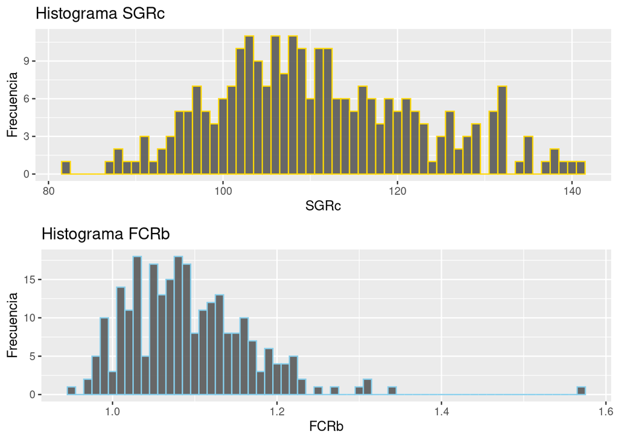

```r
knitr::opts_chunk$set(echo = TRUE)


Hist_SGRc<- BD_Jaulas %>% select("SGRc") %>% ggplot(aes(x=SGRc))+
  geom_histogram(binwidth = 1, alpha=0.9, position = "identity", color="gold")+
  ylab("Frecuencia")+
  ggtitle("Histograma SGRc")



Hist_FCRb<-BD_Jaulas %>% select("FCRb") %>% ggplot(aes(x=FCRb))+
  geom_histogram(binwidth = 0.01, alpha=0.9, position = "identity", color="skyblue")+
  ylab("Frecuencia")+
  ggtitle("Histograma FCRb")

grid.arrange(Hist_SGRc, Hist_FCRb, nrow =2)
```

## Gráfica Tamaño de los efectos SGRc

En la gráfica de tamaño de efectos para la variable SGRc es posible apreciar que el mayor efecto es producido por los Machos, con los que se obtienen los mayores valores de SGRc.

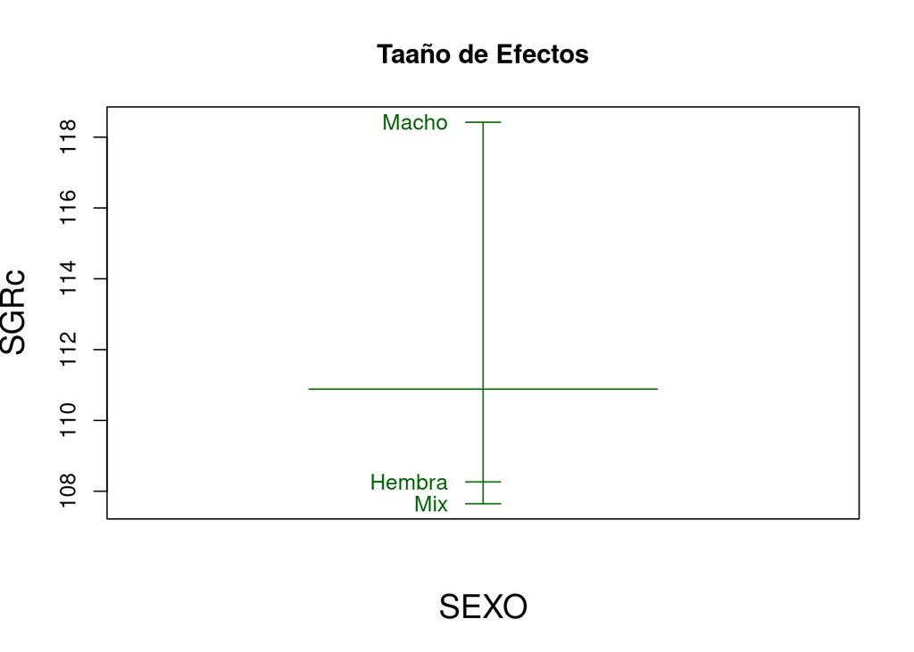

```r
knitr::opts_chunk$set(echo = TRUE)

plot.design(BD_Jaulas$SGRc ~ BD_Jaulas$SEXO,BD_Jaulas$`TIPO GRUPO`, col="darkgreen", ylab = "SGRc", xlab = "SEXO", main = "Taaño de Efectos",
            cex.lab=1.5, cex.axis=1, xaxt="n")
```

## Gráfica Tamaño de los efectos FCRb

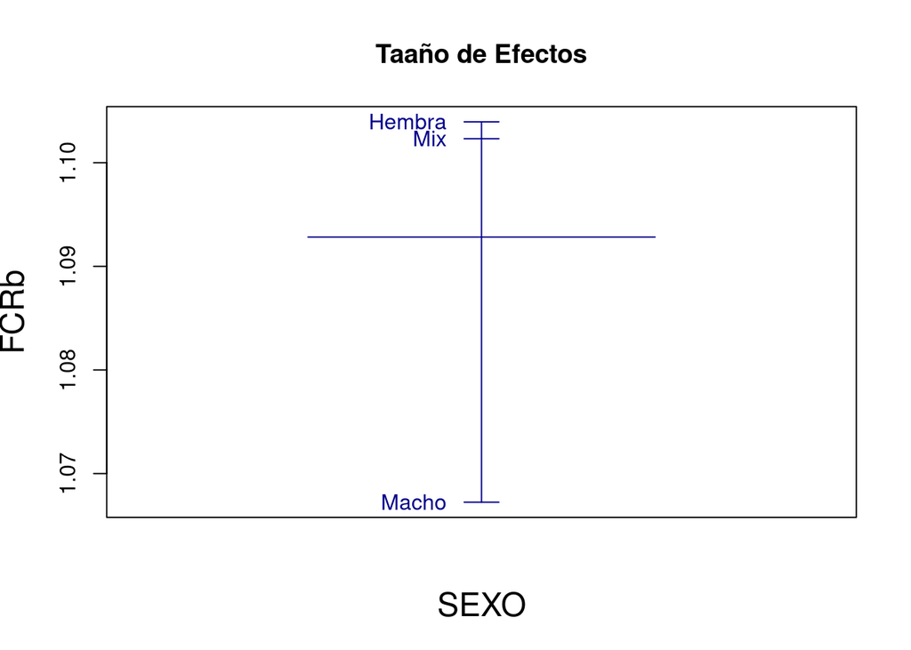

```r
knitr::opts_chunk$set(echo = TRUE)

plot.design(BD_Jaulas$FCRb ~ BD_Jaulas$SEXO,BD_Jaulas$`TIPO GRUPO`, col="darkblue", ylab = "FCRb", xlab = "SEXO", main = "Taaño de Efectos",
            cex.lab=1.5, cex.axis=1, xaxt="n")
```

## Gráficas Boxplot para categoría Sexo

En la gráfica de boxplot para la variable %SGRc es posible observar que los Machos aparentemente presentan un mayor crecimiento, por sobre las jaulas Hembra y Mix. Además se puede observar algunos “outlier” en la categoría Mix.

Para el caso de la conversión biologica (FCRb)es posbile observar que la categoría Macho presenta una conversion menor, respecto a las Hebras y jaulas Mix. Esposible observar algunos “outlier” en las tres categorías.

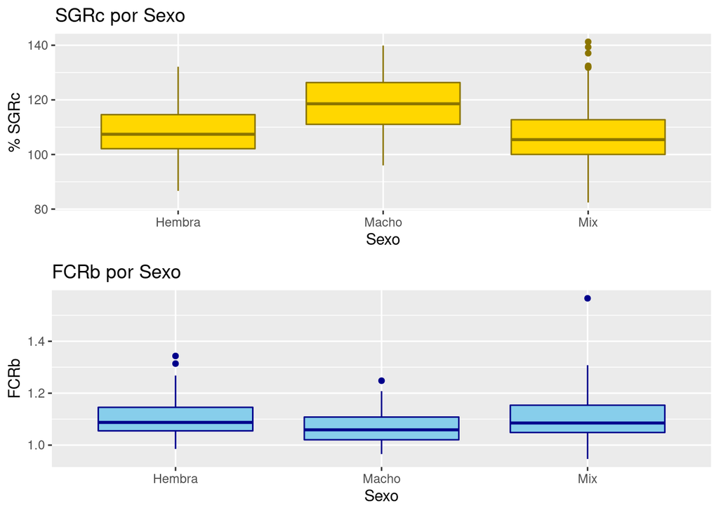

```r
knitr::opts_chunk$set(echo = TRUE)

Boxplot_SGRc_Sexo<-ggplot(BD_Jaulas, aes(x=SEXO, y=SGRc))+
geom_boxplot(color="gold4", fill="gold")+
labs(x="Sexo", y="% SGRc", title = "SGRc por Sexo")+
  theme_gray()


Boxplot_FCRb_Sexo<-ggplot(BD_Jaulas, aes(x=SEXO, y=FCRb))+
  geom_boxplot(color="darkblue", fill="skyblue")+
  labs(x="Sexo", y="FCRb", title = "FCRb por Sexo")+
  theme_gray()

grid.arrange(Boxplot_SGRc_Sexo, Boxplot_FCRb_Sexo, nrow =2)
```

## Gráficas Boxplot para categoría Cepa

Al analizar los datos, pero por su cepa de origen es posible ver que para la categoría “Growth” presenta mayores crecimientos y conversiones más bajas también.

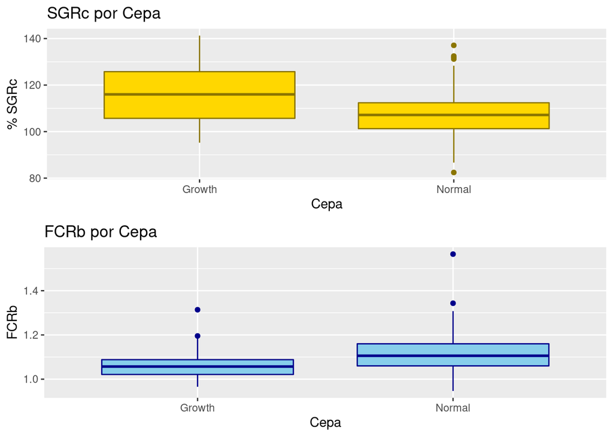

```r
knitr::opts_chunk$set(echo = TRUE)

Boxplot_SGRc_Cepa<-ggplot(BD_Jaulas, aes(x=`TIPO GRUPO`, y=SGRc))+
  geom_boxplot(color="gold4", fill="gold")+
  labs(x="Cepa", y="% SGRc", title = "SGRc por Cepa")+
  theme_gray()


Boxplot_FCRb_Cepa<-ggplot(BD_Jaulas, aes(x=`TIPO GRUPO`, y=FCRb))+
  geom_boxplot(color="darkblue", fill="skyblue")+
  labs(x="Cepa", y="FCRb", title = "FCRb por Cepa")+
  theme_gray()

grid.arrange(Boxplot_SGRc_Cepa, Boxplot_FCRb_Cepa, nrow =2)
```

## Gráficas Boxplot para categoría Sexo-Cepa

Al mezclar estas categorías, podemos ver que aparentemente los Macho_Growth presentan los mayores crecimientos, y también las menores conversiones. Por otra parte, las Hembra_Normal y Mix_Normal presentan los crecimientos más bajos y mayores conversiones.

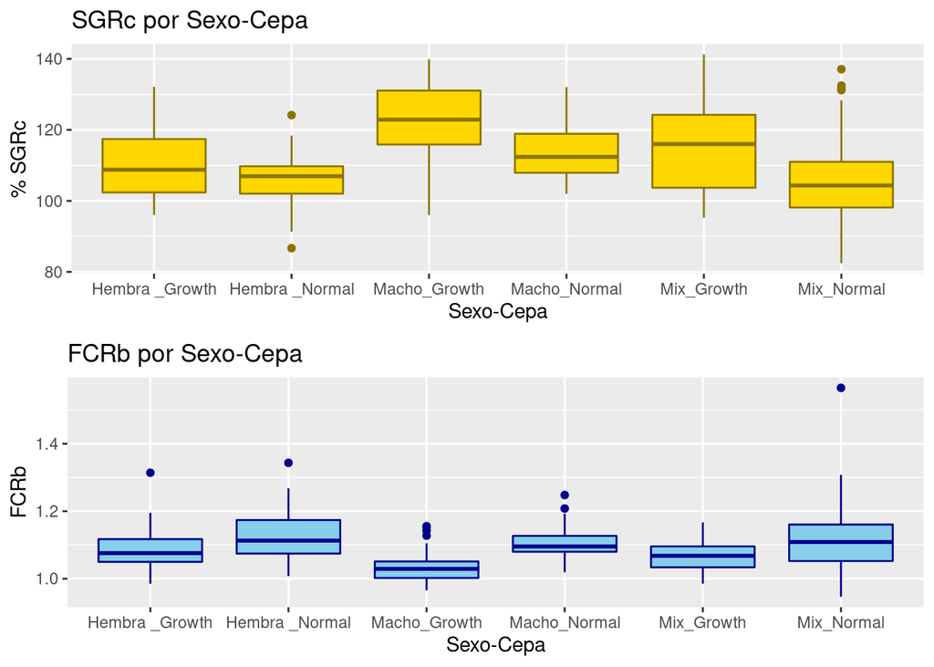

```r
knitr::opts_chunk$set(echo = TRUE)

Boxplot_SGRc_SexoCepa<-ggplot(BD_Jaulas, aes(x=Tipo_Sexo, y=SGRc))+
  geom_boxplot(color="gold4", fill="gold")+
  labs(x="Sexo-Cepa", y="% SGRc", title = "SGRc por Sexo-Cepa")+
  theme_gray()


Boxplot_FCRb_SexoCepa<-ggplot(BD_Jaulas, aes(x=Tipo_Sexo, y=FCRb))+
  geom_boxplot(color="darkblue", fill="skyblue")+
  labs(x="Sexo-Cepa", y="FCRb", title = "FCRb por Sexo-Cepa")+
  theme_gray()

grid.arrange(Boxplot_SGRc_SexoCepa, Boxplot_FCRb_SexoCepa, nrow =2)
```

## Tabla Resumen categoría **Sexo**

| **Sexo** | **Promedio % SGRc** | **D.E** |
| --- | --- | --- |
| **Hembra** | 108,3 | 9,1 |
| **Macho** | 118,4 | 10,3 |
| **Mix** | 107,6 | 12,1 |

| **Sexo** | **Promedio FCRb** | **D.E** |
| --- | --- | --- |
| **Hembra** | 1,10 | 0,07 |
| **Macho** | 1,06 | 0,06 |
| **Mix** | 1,10 | 0,08 |

## Tabla Resumen categoría **Cepa**

| **Cepa** | **Promedio % SGRc** | **D.E** |
| --- | --- | --- |
| **Growth** | 115,9 | 12,3 |
| **Normal** | 107,4 | 10,1 |

| **Sexo** | **Promedio FCRb** | **D.E** |
| --- | --- | --- |
| **Growth** | 1,06 | 0,05 |
| **Normal** | 1,11 | 0,07 |

## Tabla Resumen categoría **Cepa-Sexo**

| **Cepa** | **Promedio % SGRc** | **D.E** |
| --- | --- | --- |
| **Hembra_Growth** | 110,0 | 9,7 |
| **Hembra_Normal** | 105,9 | 7,8 |
| **Macho_Growth** | 122,5 | 10,9 |
| **Macho_Normal** | 113,4 | 7,0 |
| **Mix_Growth** | 115,1 | 13,3 |
| **Mix_Normal** | 105,6 | 11,0 |

| **Cepa** | **Promedio FCRb** | **D.E** |
| --- | --- | --- |
| **Hembra_Growth** | 1,08 | 0,06 |
| **Hembra_Normal** | 1,12 | 0,07 |
| **Macho_Growth** | 1,03 | 0,04 |
| **Macho_Normal** | 1,10 | 0,05 |
| **Mix_Growth** | 1,07 | 0,05 |
| **Mix_Normal** | 1,11 | 0,08 |